# Assignment 3 - ALY2100 CRN SEC 02 Fall 2023 CPS

Student: Margarita Kholostova

Instructor: Vladimir Shapiro

Date: September 24, 2023

## Introduction

In programming, the ability to model and predict real-world scenarios is a testament to the versatility and power of coding (OpenAI, 2023). This assignment delves into two distinct predictive models, each demonstrating the application of Python programming constructs in problem-solving. The primary focus is understanding and implementing algorithmic structures, loops, and user interactions to simulate real-world phenomena.

The first task challenges us to predict the reduction in Arctic ice thickness over a specified number of years, using loops to iterate through each year's prediction.

The second task, in contrast, is a mathematical model predicting the growth of a microorganism population, emphasizing user input validation, percentage calculations, and formatted output. Both tasks are practical examples of how fundamental Python constructs can be applied to simulate and predict real-world scenarios (OpenAI, 2023).

## Analysis

In this section you will be posting solutions to the assigment's tasks.

### Task 1 - Predicting Arctic Ice Melting

In this assignment, you will create a Python program to predict the melting of Arctic ice over a certain number of years based on the assumption that it is melting at a fixed rate. The program will take input from the user to determine the number of years they want to predict and allow them to repeat the prediction process as many times as they desire.

1. Create a Python program that implements the following functionality:

   a. Display a welcome message and brief explanation of the program's purpose.

   b. Ask the user to input the number of years they want to predict.

   c. Assume that Arctic ice is currently melting at a rate of 0.5 millimeters per year.

   d. Calculate and display the estimated reduction in Arctic ice thickness for each year based on the assumption.

   e. Ask the user if they want to make another prediction or stop the prediction process.
2. Implement a loop allowing the user to repeat the prediction process until they stop.
3. Handle invalid inputs gracefully, ensuring the program does not crash if the user enters non-numeric or negative values.

### Flowchart

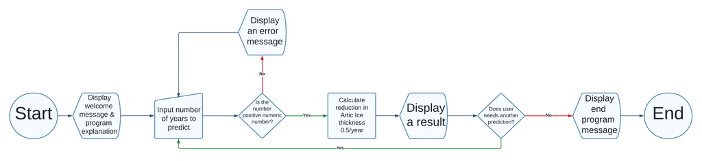

Figure 1. Flowchart for the program that predicts arctic ice melting

```python
#OpenAI. (2023). Welcome message for Arctic Ice Melting Prediction Program. Retrieved from ChatGPT conversation, September 23, 2023.
def display_welcome_message():
    print("Welcome to the Arctic Ice Melting Prediction Program!")
    print("-----------------------------------------------------")
    print("This program predicts the melting of Arctic ice over a certain number of years.")
    print("Based on the assumption that the Arctic ice is melting at a fixed rate,")
    print("you can input the number of years you wish to predict and see the results.")
    print("Feel free to run the prediction as many times as you'd like.")
    print("-----------------------------------------------------\n")


def check_for_positive_number(prompt_message):

    while True:
        years_to_predict = input(prompt_message).strip()
        if years_to_predict:
            try:
                amount = float(years_to_predict)
                #if user enters not integer, the program will round it up
                round_amount = round(amount)
                if round_amount > 0:
                    return round_amount
                elif round_amount <= 0:
                    print('Error: Negative number or zero! Try again.')
            except ValueError:
                print("Error: Invalid input! Please enter a positive integer.")
        else: print("Error: Empty input, try again!")



#start of the program
display_welcome_message()

while True:

        number = check_for_positive_number("Please provide number of years to predict in the format of positive number: ")

        print(f'Number chosen is: {number} \n')
        print("Prediction results: ")

        #printing results
        for value in range(1, number+1):
            print(f'Year {value}: {0.5*value} millimeters reduction in Arctic ice thickness')

        repeat = (input("Do you need another prediction? (yes/no)")).lower()

        if repeat == 'no' or repeat == 'n':
            print("Thank you for using the Arctic Ice Melting Predictor. Have a great day!")
            break;
```

```
Welcome to the Arctic Ice Melting Prediction Program!
-----------------------------------------------------
This program predicts the melting of Arctic ice over a certain number of years.
Based on the assumption that the Arctic ice is melting at a fixed rate,
you can input the number of years you wish to predict and see the results.
Feel free to run the prediction as many times as you'd like.
-----------------------------------------------------

Please provide number of years to predict in the format of positive number: 12
Number chosen is: 12

Prediction results:
Year 1: 0.5 millimeters reduction in Arctic ice thickness
Year 2: 1.0 millimeters reduction in Arctic ice thickness
Year 3: 1.5 millimeters reduction in Arctic ice thickness
Year 4: 2.0 millimeters reduction in Arctic ice thickness
Year 5: 2.5 millimeters reduction in Arctic ice thickness
Year 6: 3.0 millimeters reduction in Arctic ice thickness
Year 7: 3.5 millimeters reduction in Arctic ice thickness
Year 8: 4.0 millimeters reduction in Arctic ice thickness
Year 9: 4.5 millimeters reduction in Arctic ice thickness
Year 10: 5.0 millimeters reduction in Arctic ice thickness
Year 11: 5.5 millimeters reduction in Arctic ice thickness
Year 12: 6.0 millimeters reduction in Arctic ice thickness
Do you need another prediction? (yes/no)y
Please provide number of years to predict in the format of positive number: -5
Error: Negative number or zero! Try again.
Please provide number of years to predict in the format of positive number: 0.5
Error: Negative number or zero! Try again.
Please provide number of years to predict in the format of positive number: 1.5
Number chosen is: 2

Prediction results:
Year 1: 0.5 millimeters reduction in Arctic ice thickness
Year 2: 1.0 millimeters reduction in Arctic ice thickness
Do you need another prediction? (yes/no)y
Please provide number of years to predict in the format of positive number:
Error: Empty input, try again!
Please provide number of years to predict in the format of positive number: fgfsg
Error: Invalid input! Please enter a positive integer.
Please provide number of years to predict in the format of positive number: 4
Number chosen is: 4

Prediction results:
Year 1: 0.5 millimeters reduction in Arctic ice thickness
Year 2: 1.0 millimeters reduction in Arctic ice thickness
Year 3: 1.5 millimeters reduction in Arctic ice thickness
Year 4: 2.0 millimeters reduction in Arctic ice thickness
Do you need another prediction? (yes/no)n
Thank you for using the Arctic Ice Melting Predictor. Have a great day!
```

### Task 2 - Population

Write a program that predicts the approximate size of a population of microorganisms. The application should use text boxes to allow the user to enter the starting number of microorganisms, the average daily population increase (as a percentage), and the number of days the microorganisms will be left to multiply. Ask the user when they want to stop the simulation.

### Flowchart

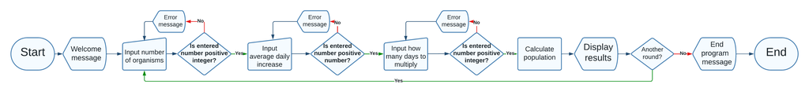

Figure 2: Flowchat for the program that will calculate population based on input parametrs

```python
# OpenAI. (2023). Welcome message for Microorganism Population Predictor. Retrieved from ChatGPT conversation, September 23, 2023.
def display_welcome_message():
    print("Welcome to the Microorganism Population Predictor!")
    print("-----------------------------------------------------")
    print("This program predicts the approximate size of a population of microorganisms.")
    print("You will be able to input the starting number of microorganisms, the average daily population increase (as a percentage), and the number of days the microorganisms will multiply.")
    print("Keep track of the growth and stop the simulation whenever you wish.")
    print("Let's get started!")
    print("-----------------------------------------------------\n")

def check_for_positive_number(prompt_message):

    while True:
        value_to_check= input(prompt_message).strip()
        if value_to_check:
            try:
                amount = float(value_to_check)
                #if user enters not integer, the program will round it up
                round_amount = round(amount)
                if round_amount > 0:
                    return round_amount
                elif round_amount <= 0:
                    print('Error: Negative number or zero! Try again.')
            except ValueError:
                print("Error: Invalid input! Please enter a positive number.")
        else: print("Error: Empty input, try again!")

def percentage_transform(prompt):

    while True:
        daily_increase_percentage = input(prompt)
        percentage = daily_increase_percentage.replace('%','').strip()
        if percentage:
            try:
                amount = float(percentage)
                if amount > 0:
                    return amount/100
                elif amount <= 0:
                    print('Error: Negative number or zero! Try again.')
            except ValueError:
                print("Error: Invalid input! Please enter a positive number.")
        else: print("Error: Empty input, try again!")




#start of the program
display_welcome_message()

while True:

        organism_num = check_for_positive_number('Starting number of organisms: ')

        daily_increase = percentage_transform("Average daily increase in percentage: ")

        days_number = check_for_positive_number('Number of days to multiply: ')

        #printing the header
        print("Day Approximate\t Population")

        #range(start, stop, step)
        for value in range(1, days_number+1):

             # Formatting the number to trim trailing zeros
            formatted_num = "{:.5f}".format(organism_num).rstrip('0').rstrip('.')

            # Modified print statement to match desired format
            print(f'{value:<17}{formatted_num:<8}')
            organism_num += organism_num * daily_increase


        repeat = (input("Do you need another calculation? (yes/no)")).lower()

        if repeat == 'no' or repeat == 'n':
            print("Thank you for using population calculator. Have a great day!")
            break;
```

[output not shown]

# Conclusions

Completing this assignment has offered valuable insights into Python's utility as a modeling and prediction tool (OpenAI, 2023).

The Arctic ice melting predictor showcased the application of loops, allowing for repeated calculations based on user-defined parameters. It also emphasized the importance of handling invalid inputs gracefully, ensuring a seamless user experience.

On the other hand, the microorganism population predictor demonstrated the integration of mathematical formulas with Python structures while showcasing formatted string output for clear presentation. Both programs reinforced the importance of user interaction, algorithmic thinking, and the practical application of Python constructs (OpenAI, 2023).

# References

1. GeeksforGeeks. (2023, September 6). Python string replace() method. GeeksforGeeks. https://www.geeksforgeeks.org/python-string-replace/
2. Guttag, J. V. (2021). Introduction to computation and programming using python, third edition: With application to computational modeling and Understanding Data. MIT Press.
3. Kalb, I. (2018). Learn to program with python 3: A step-by-step guide to programming. Apress.
4. Savio, A. (2023, May 12). How to format floats without trailing zeros?. AskPython. https://www.askpython.com/python/examples/formatting-floats-without-trailing-zeros